# Predict Proper Weight Lifting Technique with Machine Learning

Aslak Eriksen

26 7 2019

# Executive Summary

The report shows that a random forest model applied on data from accelerometers may predict if a dumbbell biceps curl is performed correctly. The random forest model was preferred to other methods, such as linear discriminant analysis (lda), boosting (gbm) and model stacking (random forest). The training data from Velloso, et al. (2013) was divided into both training and validation data - to aid the choice of prediction model without involving the test data set. With the use of the validation data, the expected out of sample error is approximately 0,6%.

# About the Analysis

The purpose of this report is to predict in what manner a weight lifting exercise is performed. The prediction is based on data from accelerometers on the belt, forearm, arm, and dumbell of 6 participants.

The data stems from the paper *Qualitative Activity Recognition of Weight Lifting Exercises* (Velloso, et al., 2013).

> “Six young health participants were asked to perform one set of 10 repetitions of the Unilateral Dumbbell Biceps Curl in five different fashions (..). Class A corresponds to the specified execution of the exercise, while the other 4 classes correspond to common mistakes.”

# Initation: Preparing the Data

## Load and Read Data

The following code shows how the data is downloaded into R.

```r
# Load packages
library(dplyr)
library(tidyverse)
library(reshape2)
library(tidyr)
library(caret)
library(AppliedPredictiveModeling)
library(parallel)
library(doParallel)
library(scales)
library(plotROC)

# Create folder 'data' if not already existing
if(!file.exists("./data")) {
  dir.create("./data")
}

# Download .csv train and test files if not already existing in 'data'
buildDataFile <- './data/pml-training.csv'
       if(!file.exists(buildDataFile))
        {
               trainFileUrl <- "https://d396qusza40orc.cloudfront.net/predmachlearn/pml-training.csv"
                download.file(trainFileUrl, destfile = "./data/pml-training.csv", method = "curl")
       }

testFile <- './data/pml-testing.csv'
       if(!file.exists(testFile))
        {
               testFileUrl <- "https://d396qusza40orc.cloudfront.net/predmachlearn/pml-testing.csv"
                download.file(testFileUrl, destfile = "./data/pml-testing.csv", method = "curl")
       }
```

The following code shows how the data is loaded into R and read into data frames.

```r
# Create data frames from read.csv
buildData <- read.csv("./data/pml-training.csv",
               header = TRUE,
               quote = "\"'",
               strip.white = TRUE,
               stringsAsFactors = F,
               sep = ",")

testing <- read.csv("./data/pml-testing.csv",
               header = TRUE,
               quote = "\"'",
               strip.white = TRUE,
               stringsAsFactors = F,
               sep = ",")
```

## Method for Cross Validation: Traning and Validation Data Set

The training data is divided into training and validation data (75% and 25%). There are many observations in the data set. It is common to only approximate the validation step - analytically or by sample re-use - when data is scarce. Consequently, we will seperate the data into both training and validation, and find a accurate prediction model without the use of the test data. The test data is reserved for evaluation of the final prediction model.

It might be argued that a validation set is not necessary when building a random forest model. The random forest model prevents overfitting by constructing each tree with a different bootstrap sample from training data. However, other methods require a validation set and the seperation is considered “good practice” within data science.

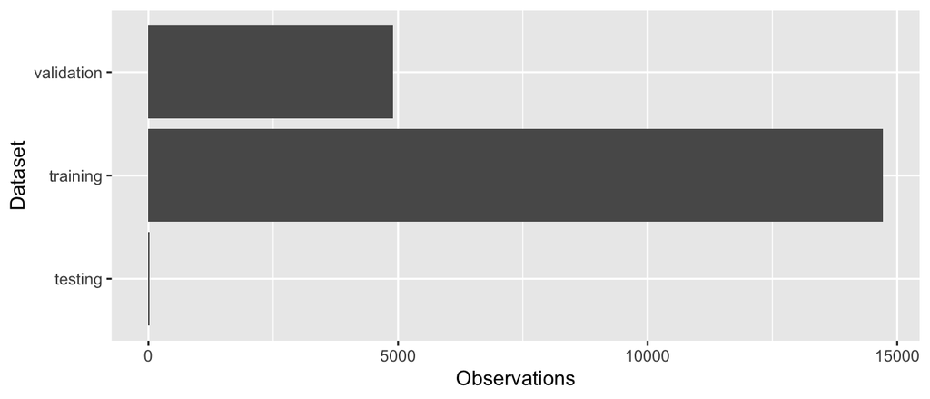

```r
# Divide 75 % training, 25 % cross validation
inBuildData = createDataPartition(buildData$classe, p = 3/4)[[1]]
training = as.data.frame(buildData[ inBuildData,])
validation = as.data.frame(buildData[-inBuildData,])

# Create dataframe with 3 values, training validation and test. New column with the count of observations.
datasetType <- c("training", "validation", "testing")
datasetObservations <- c(nrow(training), nrow(validation), nrow(testing))
observationsDF <- data.frame("Dataset" = datasetType, "Observations" = datasetObservations, stringsAsFactors = FALSE)

# Create horizontal bar chart with the proportions of observations witin the datasets. Color different.
ggplot(data = observationsDF, aes(x = Dataset, y = Observations)) + geom_bar(stat="identity") + coord_flip()
```

## Clean the Data: Only Keep the Relevant Predictors

Not all the columns in the data set are useful as predictors. It is advantageous for the prediction model if we can limit the number of predictors. This will improve the performance of the prediction model.

- Remove descriptive columns (e.g. name and timestamp) that are not relevant for a prediction model.

```r
## TRAINING DATA
training <- training %>% select(-X, -user_name, -raw_timestamp_part_1, -raw_timestamp_part_2, -cvtd_timestamp, -num_window)

## VALIDATION DATA
validation <- validation %>% select(-X, -user_name, -raw_timestamp_part_1, -raw_timestamp_part_2, -cvtd_timestamp, -num_window)

## TEST DATA
testing <- testing %>% select(-X, -user_name, -raw_timestamp_part_1, -raw_timestamp_part_2, -cvtd_timestamp, -num_window)
```

- Remove summary statistics. According to Vellose, et al. (2013), eight features - mean, variance, standard deviation, max, min, amplitude, kurtosis and skewness - are calculated from the four sensors. Hence, they are derived values. Additionally, these variables have a high percentage of missing values.

```r
## TRAINING DATA
training <- training %>%
        select(-starts_with("avg_")) %>%
        select(-starts_with("var_")) %>%
        select(-starts_with("stddev_")) %>%
        select(-starts_with("max_")) %>%
        select(-starts_with("min_")) %>%
        select(-starts_with("amplitude_")) %>%
        select(-starts_with("kurtosis_")) %>%
        select(-starts_with("skewness"))

## VALIDATION DATA
validation <- validation %>%
        select(-starts_with("avg_")) %>%
        select(-starts_with("var_")) %>%
        select(-starts_with("stddev_")) %>%
        select(-starts_with("max_")) %>%
        select(-starts_with("min_")) %>%
        select(-starts_with("amplitude_")) %>%
        select(-starts_with("kurtosis_")) %>%
        select(-starts_with("skewness"))

## TEST DATA
testing <- testing %>%
        select(-starts_with("avg_")) %>%
        select(-starts_with("var_")) %>%
        select(-starts_with("stddev_")) %>%
        select(-starts_with("max_")) %>%
        select(-starts_with("min_")) %>%
        select(-starts_with("amplitude_")) %>%
        select(-starts_with("kurtosis_")) %>%
        select(-starts_with("skewness"))
```

- Remove near zero variance predictors. These predictors will not be useful for the model.

```r
## TRAINING DATA
nzv_cols <- nearZeroVar(training)
if(length(nzv_cols) > 0) training <- training[, -nzv_cols]

## VALIDATION DATA
validation <- validation[, -nzv_cols]

## TEST DATA
testing <- testing[, -nzv_cols]
```

# Prediction Model

## Final Prediction Model: Random Forest

A random forest model - without any model stacking (combination of classifiers) - is chosen as the final prediction model. The section below describes how the model was determined through application of the training and validation data set.

## Which Prediction Models to Assess?

Our starting point is that combining predictors - ensembling - could give a accurate model. However, the increased accuracy in a complex ensemble also implies a loss of interpretability.

We will attempt to combine the following classifiers: - Random forest - Boosted predictor (Generalizer Boosted Regression Modeling method) - Linear discriminant analysis (LDA)

The method for the combined classifier is random forest.

The final prediction model is determined based on which classifier that has the best performance.

## Train and Determine Model

Train the models.

```r
# Seed for modelling - to ensure reproducibility.
set.seed(1337)

# Ensuring that parallel processing is used on computer. This is required for computing random forest and generalized boosted regression model. Otherwise, the computation will be very slow.
cluster <- makeCluster(detectCores() - 1) # convention to leave 1 core for OS
registerDoParallel(cluster)
fitControl <- trainControl(method = "cv",
                           number = 5,
                           allowParallel = TRUE)

# Random forest
set.seed(1337)
## Train model
rf.modelFit <- train(classe ~ ., method = "rf", data = training, trControl = fitControl)
## Check model on the validation set
pred1 <- predict(rf.modelFit, validation)
## Results
cm_pred1 <- confusionMatrix(table(pred1, validation$classe))
print(rf.modelFit$finalModel)

# Boosted predictor with Generalized Boosted Regression Modeling (gbm) method
set.seed(1337)
## Train model
gbm.modelFit <- train(classe ~ ., method = "gbm", data = training, trControl = fitControl)
## Check model on the validation set
pred2 <- predict(gbm.modelFit, validation)
## Results
cm_pred2 <- confusionMatrix(table(pred2, validation$classe))

# Linear discriminant analysis (lda)
set.seed(1337)
## Train model
lda.modelFit <- train(classe ~ ., method = "lda", data = training)
## Check model on the validation set
pred3 <- predict(lda.modelFit, validation)
## Results
cm_pred3 <- confusionMatrix(table(pred3, validation$classe))

# STACKED with random forest
set.seed(1337)
predDF <- data.frame(pred1, pred2, pred3, classe = validation$classe)
## Train model
combModFit <- train(classe ~ ., method = "rf", data = predDF, trControl = fitControl)
## Check model on the validation set
combPred <- predict(combModFit, predDF)
## Results
cm_combPred <- confusionMatrix(combPred, as.factor(validation$classe))

# Revert back to single threaded processing in R
stopCluster(cluster)
registerDoSEQ()
```

Retrieve the accuracy from the different models.

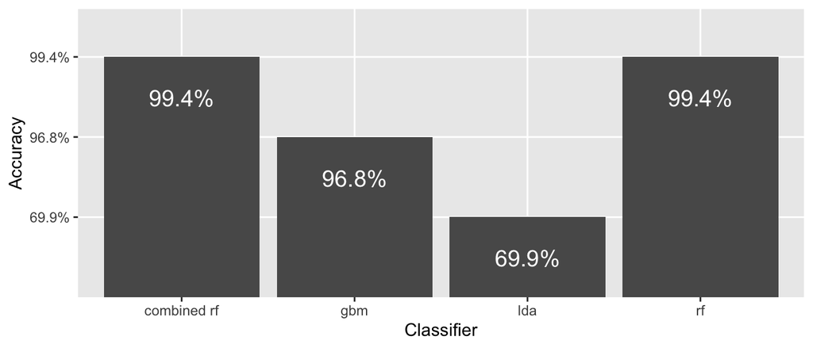

```r
# Data frame of accuracy from models
accuracy_pred1 <- cm_pred1$overall["Accuracy"]
accuracy_pred2 <- cm_pred2$overall["Accuracy"]
accuracy_pred3 <- cm_pred3$overall["Accuracy"]
accuracy_combPred <- cm_combPred$overall["Accuracy"]

x <- c("rf", "gbm", "lda", "combined rf")
y <- c(accuracy_pred1, accuracy_pred2, accuracy_pred3, accuracy_combPred)
y <- percent(y)
accuracy_df <- data.frame("Classifier" = x, "Accuracy" = y, stringsAsFactors = FALSE)
accuracy_df

# Plot of accuracy in classifiers
plot <- ggplot(data = accuracy_df, aes(x = Classifier, y = Accuracy))
plot <- plot + geom_bar(stat="identity")
plot <- plot + geom_text(aes(x= Classifier, y = Accuracy, label = Accuracy), vjust = 3, size = 5, colour = "white")
plot
```

As shown above, the accuracy of the **random forest model** is approximately equal to the combined random forest prediction model. We choose the random forest model. It is much simpler than the combined model and has more or less the same performance.

# Expected Out of Sample Error

```r
# Table of predicted values for validation set
table(pred2, validation$classe)
```

```
##
## pred2    A    B    C    D    E
##     A 1375   24    0    1    2
##     B   17  898   19    4    9
##     C    2   27  825   22    5
##     D    0    0   10  773   11
##     E    1    0    1    4  874
```

```r
error_pred1 <- percent(1-accuracy_pred1)
accuracy_pred1 <- percent(accuracy_pred1)
```

# Prediction for Test Data Set

The test data set does not answer in what manner the exercise was performed. That information is given in the quiz portion of the course project. The predicted class of the weight lifting exercise for the test data is shown below.

```r
# Table of predicted values for test data
predict(rf.modelFit, testing)
```

```
##  [1] B A B A A E D B A A B C B A E E A B B B
## Levels: A B C D E
```

# References

- Velloso, E.; Bulling, A.; Gellersen, H.; Ugulino, W.; Fuks, H. Qualitative Activity Recognition of Weight Lifting Exercises. Proceedings of 4th International Conference in Cooperation with SIGCHI (Augmented Human ’13) . Stuttgart, Germany: ACM SIGCHI, 2013.